# Prior specification

# Priors for $\beta$

For the average effect parameter $\beta$, we consider $L$-norm priors with density
$$d_\beta(b) \propto \exp\left(- \phi\left| b - \mu \right|^L \right),$$
where $\mu$ is the mean (and median and mode), $\phi$ is a precision parameter (i.e., inverse of scale), and $L$ is the norm. We consider two version of the priors, both with $\mu = 0$. As a potential default prior, we use $L = 2$ and $\phi = \frac{1}{2}$, which corresponds to a standard normal distribution. As a weaker prior, we use $L = 4$ and $\phi = \frac{1}{16}$, which produces a playtkurtic distribution that is very flat over the range $|\beta| < 0.8$ but becomes much sharper for $|\beta| > 2$. Figure 1 depicts the densities of these prior distributions, with the default in red and the weaker prior in purple.

**Density**

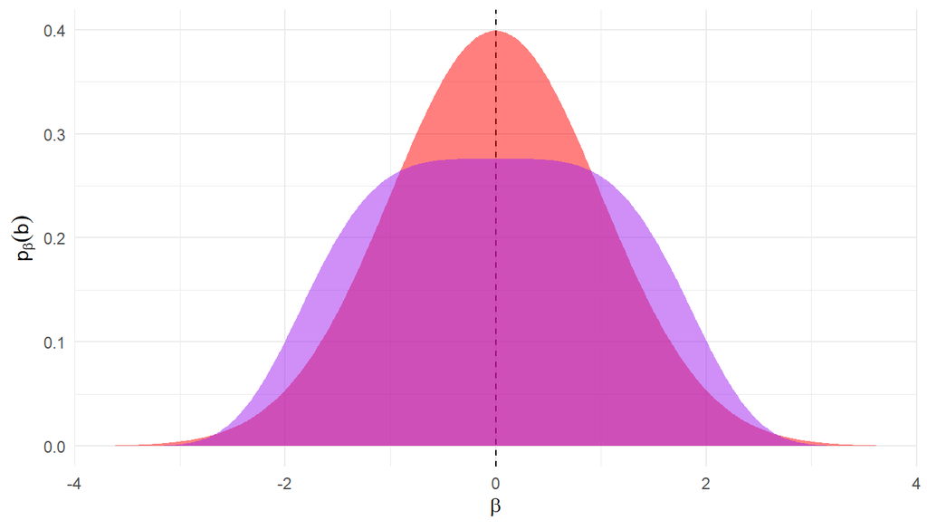

Figure 1: Prior distributions on $\beta$

```r
Lp_dist <- function(mu = 0, precision = 1, L = 2, ...) {
  Const <- gamma(1 / L) * 2 / (L * precision^(1 / L))
  f <- function(x) exp(-precision * abs(x - mu)^L) / Const
  g <- function(x) sapply(x, \(y) integrate(f, lower = -Inf, upper = y, ...)$value)

  return(list(pdf = f, cdf = g))
}


beta_default <- Lp_dist(mu = 0, precision = 1 / 2, L = 2)
beta_weak <- Lp_dist(mu = 0, precision = 1 / 16, L = 4)

x <- seq(-4, 4, length.out = 500)

beta_density_dat <-
  tibble(
    beta = x,
    default = beta_default$pdf(x),
    weak = beta_weak$pdf(x)
  )

ggplot(beta_density_dat) +
  geom_vline(xintercept = 0, linetype = "dashed") +
  geom_area(aes(beta, default), fill = "red", alpha = 0.5) +
  geom_area(aes(beta, weak), fill = "purple", alpha = 0.5) +
  scale_x_continuous(expand = expansion(0,0)) +
  labs(
    x = expression(beta),
    y = expression(p[beta](b))
  )
```

**Log-density**

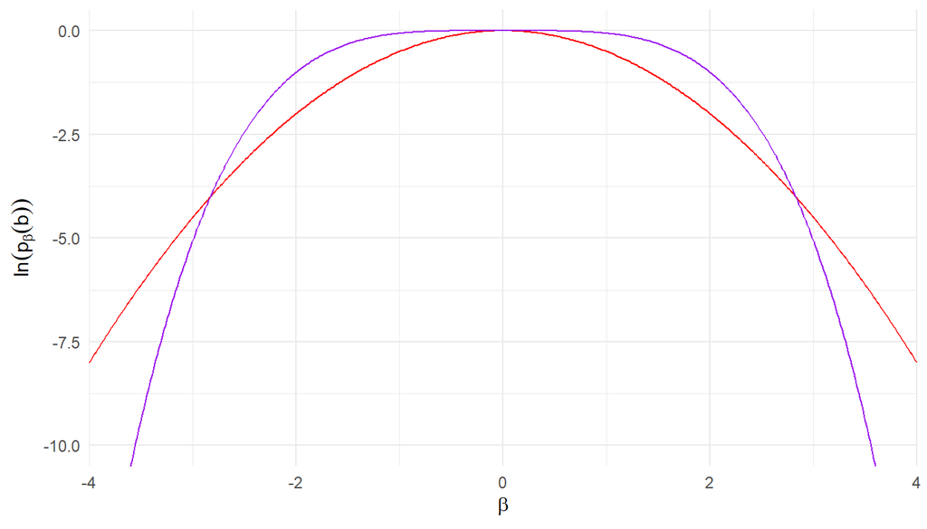

Figure 2: Log of prior densities on $\beta$

```r
beta_density_dat %>%
  mutate(
    across(c(default, weak), ~ log(.x) - max(log(.x)))
  ) %>%
  ggplot() +
  geom_line(aes(beta, default), color = "red") +
  geom_line(aes(beta, weak), color = "purple") +
  scale_x_continuous(expand = expansion(0,0)) +
  coord_cartesian(ylim = c(-10,0)) +
  labs(
    x = expression(beta),
    y = expression(ln(p[beta](b)))
  )
```

To further interpret these priors, we can consider 1) the density at benchmark values of $\beta$ relative to the density at the center of the distribution and 2) the total prior probability of $|\beta| < b$ for various values of $b$. Table 1 reports these quantities for both the default and weaker priors. The columns labelled “Relative density” correspond to $d_\beta(b) / d_\beta(0)$; the columns labelled “Prior probability” correspond to $\text{Pr}(|\beta| < b)$.

```r
x_bench <- c(0.25, 0.5, 0.8, seq(1, 3, 0.5))


tibble(
  beta_b = x_bench,
  d_Default = beta_default$pdf(x_bench) / beta_default$pdf(0),
  d_Weaker = beta_weak$pdf(x_bench) / beta_weak$pdf(0),
  c_Default = 2 * (beta_default$cdf(x_bench) - 0.5),
  c_Weaker = 2 * (beta_weak$cdf(x_bench) - 0.5),
) %>%
  flextable() %>%
  separate_header() %>%
  labelizor(labels = c('beta' = "",'d' = "Relative density", 'c' = "Prior probability")) %>%
  colformat_double(j = 2:5, digits = 3)
```

Table 1: Relative density and total probability for benchmark values of $\beta$

| b | Relative density Default | Relative density Weaker | Prior probability Default | Prior probability Weaker |
| --- | --- | --- | --- | --- |
| 0.25 | 0.969 | 1.000 | 0.197 | 0.138 |
| 0.50 | 0.882 | 0.996 | 0.383 | 0.276 |
| 0.80 | 0.726 | 0.975 | 0.576 | 0.439 |
| 1.00 | 0.607 | 0.939 | 0.683 | 0.545 |
| 1.50 | 0.325 | 0.729 | 0.866 | 0.779 |
| 2.00 | 0.135 | 0.368 | 0.954 | 0.932 |
| 2.50 | 0.044 | 0.087 | 0.988 | 0.990 |
| 3.00 | 0.011 | 0.006 | 0.997 | 1.000 |

# Priors for $\zeta$ (log of the selection parameter)

For the selection parameter $\zeta = \log(\lambda)$, we consider $L$-norm priors with density
$$d_\zeta(z) \propto \exp\left(- \phi\left| z - \mu \right|^L \right),$$
where $\mu$ is the mean (and median and mode), $\phi$ is a precision parameter (i.e., inverse of scale), and $L$ is the norm. We consider two version of the priors. As a potential default prior, we use $L = 2$, $\mu = \log(0.8)$, and $\phi = \frac{1}{2}$, which implies that $\zeta$ follows a normal distribution with mode of $\mu$ and a standard deviation of 1 (i.e., $\lambda$ follows a log-normal distribution). As a weaker prior, we use $L = 4$, $\mu = \log(0.5)$, and $\phi = \frac{1}{16}$, which produces a playtkurtic distribution that is very flat over the range $0.2 < \lambda < 1$ but becomes much sharper for $\lambda < 0.05$ or $\lambda > 5$. Figure 3 depicts the densities of these prior distributions, with the default in red and the weaker prior in purple.

**Density**

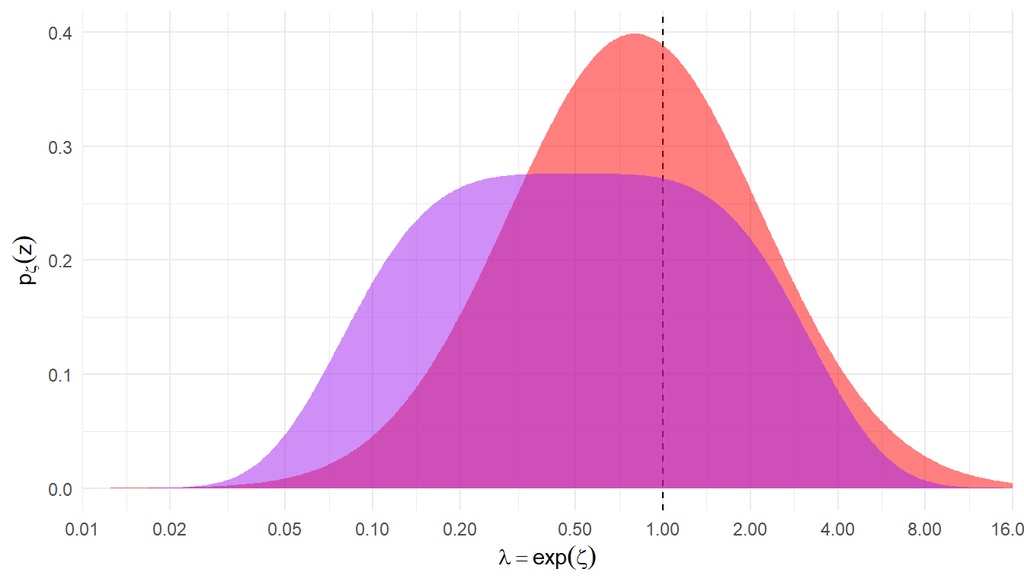

Figure 3: Prior distributions on $\zeta$

```r
z <- seq(log(0.01), log(16), length.out = 500)
lambda_bench <- c(0.01, 0.02, 0.05, 0.10, 0.20, 0.50, 0.8, 1, 1.5, 2, 4, 8, 16)
z_bench <- log(lambda_bench)

zeta_default <- Lp_dist(mu = log(0.8), precision = 1 / 2, L = 2)
zeta_weak <- Lp_dist(mu = log(0.5), precision = 1 / 16, L = 4)


zeta_density_dat <-
  tibble(
    zeta = z,
    lambda = exp(z),
    default = zeta_default$pdf(z),
    weak = zeta_weak$pdf(z)
  )

ggplot(zeta_density_dat) +
  geom_vline(xintercept = 1, linetype = "dashed") +
  geom_area(aes(lambda, default), fill = "red", alpha = 0.5) +
  geom_area(aes(lambda, weak), fill = "purple", alpha = 0.5) +
  scale_x_continuous(
    transform = "log",
    breaks = lambda_bench[c(1:6,8,10:13)],
    expand = expansion(0,0)
  ) +
  labs(
    x = expression(lambda == exp(zeta)),
    y = expression(p[zeta](z))
  )
```

**Log-density**

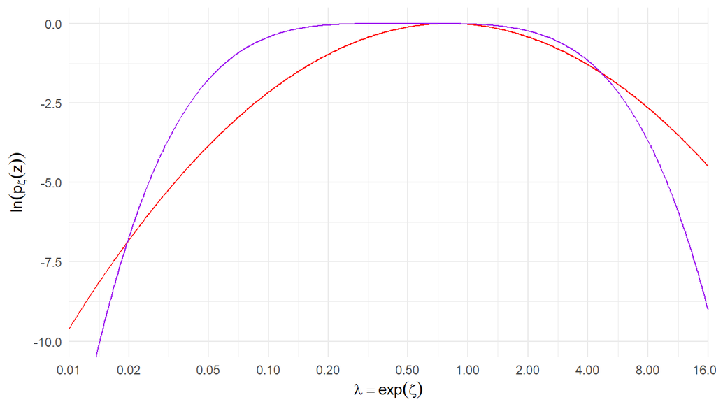

Figure 4: Log of prior densities on $\zeta$

```r
zeta_density_dat %>%
  mutate(
    across(c(default, weak), ~ log(.x) - max(log(.x)))
  ) %>%
  ggplot() +
  geom_line(aes(lambda, default), color = "red") +
  geom_line(aes(lambda, weak), color = "purple") +
  scale_x_continuous(
    transform = "log",
    breaks = lambda_bench[c(1:6,8,10:13)],
    expand = expansion(0,0)
  ) +
  coord_cartesian(ylim = c(-10,0)) +
  labs(
    x = expression(lambda == exp(zeta)),
    y = expression(ln(p[zeta](z)))
  )
```

To further interpret these priors, we can consider 1) the density at benchmark values of $\lambda$ relative to the density at $\lambda = 1$ (or $\zeta = 0$) and 2) the cumulative prior probability of $\lambda < l$ for various values of $l$. Table 2 reports these quantities for both the default and weaker priors. The columns labelled “Relative density” correspond to $d_\zeta(l) / d_\zeta(1)$; the columns labelled “Cumulative probability” correspond to $\text{Pr}(\lambda < l)$.

```r
tibble(
  lambda_l = lambda_bench,
  zeta_z = z_bench,
  d_Default = zeta_default$pdf(z_bench) / zeta_default$pdf(0),
  d_Weaker = zeta_weak$pdf(z_bench) / zeta_weak$pdf(0),
  c_Default = zeta_default$cdf(z_bench),
  c_Weaker = zeta_weak$cdf(z_bench)
) %>%
  flextable() %>%
  separate_header() %>%
  labelizor(labels = c('lambda' = "",'zeta' = "",'d' = "Relative density", 'c' = "Cumulative probability")) %>%
  colformat_double(j = 2:6, digits = 3)
```

Table 2: Relative density and total probability for benchmark values of $\lambda$

| l | z | Relative density Default | Relative density Weaker | Cumulative probability Default | Cumulative probability Weaker |
| --- | --- | --- | --- | --- | --- |
| 0.01 | -4.605 | 0.000 | 0.000 | 0.000 | 0.000 |
| 0.02 | -3.912 | 0.001 | 0.001 | 0.000 | 0.000 |
| 0.05 | -2.996 | 0.022 | 0.175 | 0.003 | 0.012 |
| 0.10 | -2.303 | 0.118 | 0.667 | 0.019 | 0.089 |
| 0.20 | -1.609 | 0.392 | 0.971 | 0.083 | 0.249 |
| 0.50 | -0.693 | 0.918 | 1.015 | 0.319 | 0.500 |
| 0.80 | -0.223 | 1.025 | 1.011 | 0.500 | 0.630 |
| 1.00 | 0.000 | 1.000 | 1.000 | 0.588 | 0.691 |
| 1.50 | 0.405 | 0.841 | 0.926 | 0.735 | 0.798 |
| 2.00 | 0.693 | 0.674 | 0.805 | 0.820 | 0.866 |
| 4.00 | 1.386 | 0.281 | 0.315 | 0.946 | 0.973 |
| 8.00 | 2.079 | 0.072 | 0.025 | 0.989 | 0.999 |
| 16.00 | 2.773 | 0.012 | 0.000 | 0.999 | 1.000 |

# Priors for $\gamma$ (log of the heterogeneity)

**Density**

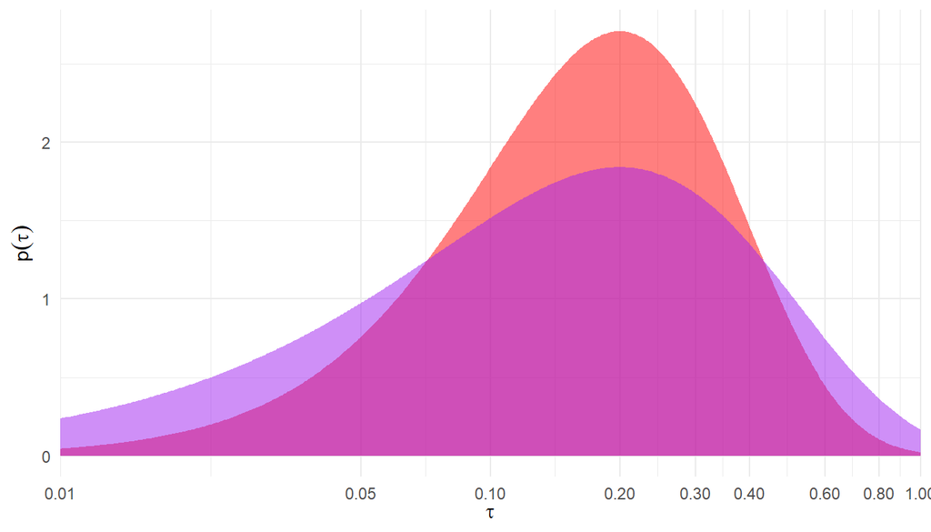

Figure 5: Prior distributions on $\gamma$

```r
loggamma_dist <- function(mode, alpha, ...) {
  lambda <- alpha / mode
  f <- function(x) dgamma(exp(x / 2), shape = alpha + 1, rate = lambda)
  g <- function(x) pgamma(exp(x / 2), shape = alpha, rate = lambda)
  return(list(pdf = f, cdf = g))
}

g <- seq(log(0.01^2), log(1^2), length.out = 500)
tau_bench <- c(0.01, 0.05, seq(0.1, 0.4, 0.1), seq(0.6, 1, 0.2))
g_bench <- 2 * log(tau_bench)

gamma_default <- loggamma_dist(mode = 0.2, alpha = 2)
gamma_weak <- loggamma_dist(mode = 0.2, alpha = 1)


gamma_density_dat <-
  tibble(
  gamma = g,
  tau = exp(g / 2),
  default = gamma_default$pdf(g),
  weak = gamma_weak$pdf(g),
)

ggplot(gamma_density_dat) +
  geom_area(aes(tau, default), fill = "red", alpha = 0.5) +
  geom_area(aes(tau, weak), fill = "purple", alpha = 0.5) +
  scale_x_continuous(
    transform = "log",
    breaks = tau_bench,
    expand = expansion(0,0)
  ) +
  labs(
    x = expression(tau),
    y = expression(p(tau))
  )
```

**Log-density**

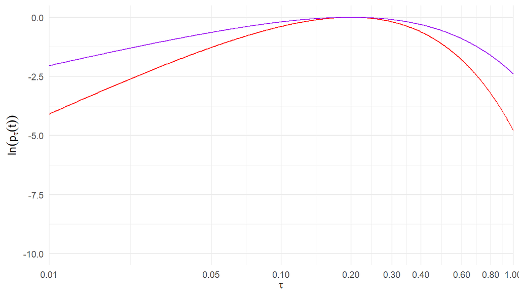

Figure 6: Log of prior densities on $\gamma$

```r
gamma_density_dat %>%
  mutate(
    across(c(default, weak), ~ log(.x) - max(log(.x)))
  ) %>%
  ggplot() +
  geom_line(aes(tau, default), color = "red") +
  geom_line(aes(tau, weak), color = "purple") +
  scale_x_continuous(
    transform = "log",
    breaks = tau_bench,
    expand = expansion(0,0)
  ) +
  coord_cartesian(ylim = c(-10,0)) +
  labs(
    x = expression(tau),
    y = expression(ln(p[tau](t)))
  )
```

To further interpret these priors, we can consider 1) the density at benchmark values of $\tau$ relative to the density at the mode $\psi$ and 2) the cumulative prior probability of $\tau < t$ for various values of $t$. Table 3 reports these quantities for both the default and weaker priors. The columns labelled “Relative density” correspond to $d_\gamma(g) / d_\gamma\left(2\log(\psi)\right)$; the columns labelled “Cumulative probability” correspond to $\text{Pr}(\gamma < g)$.

```r
tibble(
  tau_t = tau_bench,
  gamma_g = g_bench,
  d_Default = gamma_default$pdf(g_bench) / gamma_default$pdf(2 * log(0.2)),
  d_Weaker = gamma_weak$pdf(g_bench) / gamma_weak$pdf(2 * log(0.2)),
  c_Default = gamma_default$cdf(g_bench),
  c_Weaker = gamma_weak$cdf(g_bench)
) %>%
  flextable() %>%
  separate_header() %>%
  labelizor(labels = c('tau' = "",'gamma' = "",'d' = "Relative density", 'c' = "Cumulative probability")) %>%
  colformat_double(j = 2:6, digits = 3)
```

Table 3: Relative density and total probability for benchmark values of $\tau$

| t | g | Relative density Default | Relative density Weaker | Cumulative probability Default | Cumulative probability Weaker |
| --- | --- | --- | --- | --- | --- |
| 0.01 | -9.210 | 0.017 | 0.129 | 0.005 | 0.049 |
| 0.05 | -5.991 | 0.280 | 0.529 | 0.090 | 0.221 |
| 0.10 | -4.605 | 0.680 | 0.824 | 0.264 | 0.393 |
| 0.20 | -3.219 | 1.000 | 1.000 | 0.594 | 0.632 |
| 0.30 | -2.408 | 0.828 | 0.910 | 0.801 | 0.777 |
| 0.40 | -1.833 | 0.541 | 0.736 | 0.908 | 0.865 |
| 0.60 | -1.022 | 0.165 | 0.406 | 0.983 | 0.950 |
| 0.80 | -0.446 | 0.040 | 0.199 | 0.997 | 0.982 |
| 1.00 | 0.000 | 0.008 | 0.092 | 1.000 | 0.993 |